# phylociraptor

**Analysis report - 27 November, 2025 - 09:36 UTC - version: 1.0.0**

# Setup

**Location of genomes files:**

```
results/assemblies
```

**Total number of included genomes:** 20  
**Locally provided genomes:** 0  
**Successfully downloaded genomes:** 20  
**Failed species downloads:** 0  
**Not downloaded:**  
**Information on successfully downloaded genomes:**

| id | assembly_accession | bioproject | biosample | wgs_master | refseq_category | taxid | species_taxid | organism_name | infraspecific_name | isolate | version_status | assembly_level | release_type | genome_rep | seq_rel_date | asm_name | submitter | gbrs_paired_asm | paired_asm_comp | ftp_path |  |
| --- | --- | --- | --- | --- | --- | --- | --- | --- | --- | --- | --- | --- | --- | --- | --- | --- | --- | --- | --- | --- | --- |
| Amanita_muscaria | 33323 | GCA_000827485.1 | PRJNA207684 | SAMN02746075 | JMDV00000000.1 | reference genome | 946122 | 41956 | Amanita muscaria Koide BX008 | strain=Koide BX008 | na | latest | Scaffold | Major | Full | 2015-01-27 | Amanita muscaria Koide BX008 v1.0 | DOE Joint Genome Institute | na | na | https://ftp.ncbi.nlm.nih.gov/genomes/all/GCA/000/827/485/GCA_000827485.1_Amanita_muscaria_Koide_BX008_v1.0 |
| Aspergillus_nidulans | 354 | GCA_000011425.1 | PRJEA40559 | SAMEA2272224 | na | reference genome | 227321 | 162425 | Aspergillus nidulans FGSC A4 | strain=FGSC A4 | na | latest | Chromosome | Major | Full | 2009-09-24 | ASM1142v1 | Eurofungbase (Eurofung) | GCF_000011425.1 | identical | https://ftp.ncbi.nlm.nih.gov/genomes/all/GCA/000/011/425/GCA_000011425.1_ASM1142v1 |
| Bullera_alba | 70961 | GCA_001600095.1 | PRJDB3685 | SAMD00028405 | BCIX00000000.1 | reference genome | 157611 | 157611 | Bullera alba | strain=JCM 2954 | na | latest | Scaffold | Major | Full | 2016-03-01 | JCM_2954_assembly_v001 | RIKEN Center for Life Science Technologies, Division of Genomic Technologies | na | na | https://ftp.ncbi.nlm.nih.gov/genomes/all/GCA/001/600/095/GCA_001600095.1_JCM_2954_assembly_v001 |
| Calocera_cornea | 72518 | GCA_001632435.1 | PRJNA210204 | SAMN02745930 | LKHQ00000000.1 | reference genome | 1353952 | 29889 | Calocera cornea HHB12733 | strain=HHB12733 | na | latest | Scaffold | Major | Full | 2016-04-27 | Calco1 | DOE Joint Genome Institute | na | na | https://ftp.ncbi.nlm.nih.gov/genomes/all/GCA/001/632/435/GCA_001632435.1_Calco1 |
| Capronia_coronata | 21653 | GCA_000585585.1 | PRJNA164585 | SAMN00974099 | AMWN00000000.1 | reference genome | 1182541 | 43229 | Capronia coronata CBS 617.96 | strain=CBS 617.96 | na | latest | Scaffold | Major | Full | 2014-03-05 | Capr_coro_CBS_617_96_V1 | Broad Institute | GCF_000585585.1 | identical | https://ftp.ncbi.nlm.nih.gov/genomes/all/GCA/000/585/585/GCA_000585585.1_Capr_coro_CBS_617_96_V1 |
| Fistulina_hepatica | 38411 | GCA_000934395.1 | PRJNA196028 | SAMN02746049 | JYFI00000000.1 | reference genome | 1128425 | 40457 | Fistulina hepatica ATCC 64428 | strain=ATCC 64428 | na | latest | Scaffold | Major | Full | 2015-02-26 | Fishe1 | DOE Joint Genome Institute | na | na | https://ftp.ncbi.nlm.nih.gov/genomes/all/GCA/000/934/395/GCA_000934395.1_Fishe1 |
| Glomus_cerebriforme | 167279 | GCA_003550305.1 | PRJNA430010 | SAMN08364855 | QKYT00000000.1 | reference genome | 658196 | 658196 | Glomus cerebriforme | strain=DAOM 227022 | na | latest | Scaffold | Major | Full | 2018-09-12 | ASM355030v1 | INRA | na | na | https://ftp.ncbi.nlm.nih.gov/genomes/all/GCA/003/550/305/GCA_003550305.1_ASM355030v1 |
| Hemileia_vastatrix | 143147 | GCA_003057935.1 | PRJNA235221 | SAMN01919679 | PZQQ00000000.1 | na | 1291517 | 203904 | Hemileia vastatrix HvCat | na | na | latest | Scaffold | Major | Full | 2018-04-19 | ASM305793v1 | National center for Coffee Research | na | na | https://ftp.ncbi.nlm.nih.gov/genomes/all/GCA/003/057/935/GCA_003057935.1_ASM305793v1 |
| Hygrocybe_conica | 2746005 | GCA_900068975.1 | PRJEB8570 | SAMEA3267770 | CEMM00000000.1 | na | 104224 | 104224 | Hygrocybe conica | na | na | latest | Scaffold | Major | Full | 2020-07-09 | Hygrocybe_1_8 | Royal Botanic Gardens, Kew | na | na | https://ftp.ncbi.nlm.nih.gov/genomes/all/GCA/900/068/975/GCA_900068975.1_Hygrocybe_1_8 |
| Mucor_racemosus | 27153 | GCA_000697255.1 | PRJNA211902 | SAMN02371509 | JNEI00000000.1 | na | 1357677 | 4841 | Mucor racemosus B9645 | strain=B9645 | na | latest | Contig | Major | Full | 2014-06-02 | MucRacB9645-1.0 | IGS | na | na | https://ftp.ncbi.nlm.nih.gov/genomes/all/GCA/000/697/255/GCA_000697255.1_MucRacB9645-1.0 |

[output cut: 10 more lines]

# Orthology

Used orthology method: busco

Analysis hash for step orthology: cdf1597951  
Analysis hash for step filter-orthology: 9721ad5446

**Location of BUSCO results:**

```
results/orthology/busco/busco_runs/fungi-seed--genes-20_odb10.cdf1597951
```

**Used BUSCO set:** fungi-seed–genes-20_odb10

**Total number of BUSCO genes in BUSCO set:** 20  
**Number of BUSCO genes recovered in too few (4) samples:** 0  
**BUSCO genes below threshold:**  
none

**Number of samples with single-copy BUSCO score below threshold (0.2):** 1  
**Genomes below threshold:**  
Uromyces_transversalis

**Orthology overview table:**

|  | single_copy | duplicated | fragmented | missing |
| --- | --- | --- | --- | --- |
| Amanita_muscaria.7e7bee99e1 | 20 | 0 | 0 | 0 |
| Aspergillus_nidulans.7e7bee99e1 | 20 | 0 | 0 | 0 |
| Bullera_alba.7e7bee99e1 | 20 | 0 | 0 | 0 |
| Calocera_cornea.7e7bee99e1 | 18 | 0 | 1 | 1 |
| Capronia_coronata.7e7bee99e1 | 20 | 0 | 0 | 0 |
| Fistulina_hepatica.7e7bee99e1 | 19 | 0 | 1 | 0 |
| Glomus_cerebriforme.7e7bee99e1 | 19 | 1 | 0 | 0 |
| Hemileia_vastatrix.7e7bee99e1 | 19 | 0 | 0 | 1 |
| Hygrocybe_conica.7e7bee99e1 | 19 | 1 | 0 | 0 |
| Mucor_racemosus.7e7bee99e1 | 17 | 3 | 0 | 0 |

[output cut: 10 more lines]

# Alignments

## full alignments

**Location of alignment files:**

```
results/alignments/full
```

**Used aligner(s) and settings:**  
**1.** clustalo  
**2.** muscle  
**3.** mafft –quiet –auto  
**4.** tcoffee  
**Parsimony informative sites cutoff (nparsimony):** 50  
**Relative composition variability (rcv) cutoff:** 0.2  
**Number of alignments for clustalo.7616147827:** 20  
**Number of alignments for muscle.508b72fe5b:** 20  
**Number of alignments for mafft.be57cd45d0:** 20  
**Number of alignments for tcoffee.bf1f54cfe6:** 20  
**Overview of individual full alignments:**

[interactive table not shown]

## trimmed alignments

**Location of trimmed alignment files:**

```
results/alignments/trimmed
```

**Parsimony informative sites cutoff:** 50  
**Relative composition variability (rcv) cutoff:** 0.2

**Number of trimmed alignments for clustalo-trimal.c502a8c318:** 20  
**Number of trimmed alignments for muscle-trimal.6b35236ed9:** 20  
**Number of trimmed alignments for mafft-trimal.337ec35bfa:** 20  
**Number of trimmed alignments for tcoffee-trimal.c7c17972a7:** 20  
**Number of trimmed alignments for clustalo-aliscore.06dbabd784:** 20  
**Number of trimmed alignments for muscle-aliscore.e9c96289f0:** 20  
**Number of trimmed alignments for mafft-aliscore.f8b2fddd6d:** 20  
**Number of trimmed alignments for tcoffee-aliscore.12697a36f8:** 20  
**Number of trimmed alignments for clustalo-bmge.e30e58d77d:** 20  
**Number of trimmed alignments for muscle-bmge.0318581a17:** 20  
**Number of trimmed alignments for mafft-bmge.f74da90c4f:** 20  
**Number of trimmed alignments for tcoffee-bmge.0b0a056e52:** 20  
**Number of trimmed alignments for clustalo-clipkit.4fc0af9c68:** 20  
**Number of trimmed alignments for muscle-clipkit.e04802c2e2:** 20  
**Number of trimmed alignments for mafft-clipkit.764685ac44:** 20  
**Number of trimmed alignments for tcoffee-clipkit.b227885471:** 20  
**Overview of individual trimmed alignments:**

[interactive table not shown]

## filtered alignments

**Location of filtered alignment files:**

```
results/alignments/filtered
```

**Parsimony informative sites cutoff:** 50  
**Relative composition variability (rcv) cutoff:** 0.2

**Number of filtered alignments for clustalo-trimal.4c0c1e6aff:** 16  
**Number of filtered alignments for muscle-trimal.1ed0df77a7:** 17  
**Number of filtered alignments for mafft-trimal.3e72cc3686:** 15  
**Number of filtered alignments for tcoffee-trimal.00a06330d3:** 17  
**Number of filtered alignments for clustalo-aliscore.056d358508:** 17  
**Number of filtered alignments for muscle-aliscore.a2bde35ddb:** 17  
**Number of filtered alignments for mafft-aliscore.0d4a8c208c:** 17  
**Number of filtered alignments for tcoffee-aliscore.4f2d10b7d3:** 17  
**Number of filtered alignments for clustalo-bmge.b680f87fa4:** 15  
**Number of filtered alignments for muscle-bmge.895ec0d1f6:** 15  
**Number of filtered alignments for mafft-bmge.ede8803b9c:** 15  
**Number of filtered alignments for tcoffee-bmge.8b1719aa83:** 15  
**Number of filtered alignments for clustalo-clipkit.d4c3fb766a:** 18  
**Number of filtered alignments for muscle-clipkit.534330b5ca:** 17  
**Number of filtered alignments for mafft-clipkit.424ef0e65f:** 17  
**Number of filtered alignments for tcoffee-clipkit.50d88a1bf2:** 17  
**Overview of individual filtered alignments:**

[interactive table not shown]

**Show additional figures**

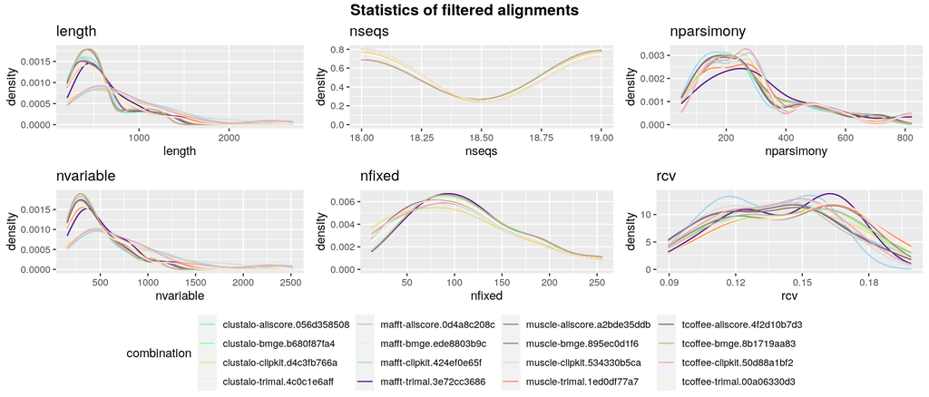

# Modeltesting

**Location of modeltesting files:**

```
results/modeltest
```

**Overview of individual modeltest results:**

| alignment | clustalo-trimal | muscle-trimal | mafft-trimal | tcoffee-trimal | clustalo-aliscore | muscle-aliscore | mafft-aliscore | tcoffee-aliscore | clustalo-bmge | muscle-bmge | mafft-bmge | tcoffee-bmge | clustalo-clipkit | muscle-clipkit | mafft-clipkit | tcoffee-clipkit |
| --- | --- | --- | --- | --- | --- | --- | --- | --- | --- | --- | --- | --- | --- | --- | --- | --- |
| 101133at4751 | LG+I+G4 | LG+I+G4 | LG+I+G4 | LG+I+G4 | LG+I+G4 | LG+I+G4 | LG+I+G4 | LG+I+G4 | LG+I+G4 | LG+I+G4 | LG+I+G4 | LG+I+G4 | LG+I+G4 | LG+I+G4 | LG+I+G4 | LG+I+G4 |
| 126519at4751 | LG+I+G4 | LG+I+G4 | LG+I+G4 | LG+G4 | LG+I+G4 | LG+G4 | LG+G4 | LG+G4 | LG+I+G4 | LG+I+G4 | LG+G4 | LG+G4 | LG+I+G4 | LG+I+G4 | LG+I+G4 | LG+I+G4 |
| 129520at4751 | WAG+I+G4 | WAG+I+G4 | LG+I+G4 | WAG+I+G4 | WAG+I+G4 | WAG+I+G4 | WAG+I+G4 | WAG+I+G4 | WAG+I+G4 | WAG+I+G4 | WAG+I+G4 | WAG+I+G4 | WAG+I+G4 | WAG+I+G4 | WAG+I+G4 | WAG+I+G4 |
| 20600at4751 | LG+I+G4 | LG+I+G4 | LG+I+G4 | LG+I+G4 | LG+I+G4 | LG+I+G4 | LG+I+G4 | LG+I+G4 | LG+I+G4 | LG+I+G4 | LG+I+G4 | LG+I+G4 | LG+I+G4 | LG+I+G4 | LG+I+G4 | LG+I+G4 |
| 23198at4751 | LG+I+G4 | LG+I+G4 | LG+I+G4 | LG+I+G4 | LG+I+G4 | LG+I+G4 | LG+I+G4 | LG+I+G4 | LG+I+G4 | LG+I+G4 | LG+I+G4 | LG+I+G4 | LG+I+G4 | LG+I+G4 | LG+I+G4 | LG+I+G4 |
| 235463at4751 | LG+G4 | LG+G4 | LG+G4 | LG+G4 | LG+G4 | LG+G4 | LG+R3 | LG+G4 | LG+G4 | LG+G4 | LG+G4 | LG+G4 | LG+G4 | LG+G4 | LG+G4 | LG+G4 |
| 244066at4751 | LG+I+G4 | LG+I+G4 | LG+I+G4 | LG+I+G4 | LG+I+G4 | LG+I+G4 | LG+I+G4 | LG+I+G4 | LG+I+G4 | LG+I+G4 | LG+I+G4 | LG+I+G4 | LG+I+G4 | LG+I+G4 | LG+I+G4 | LG+I+G4 |
| 245900at4751 | WAG+I+G4 | WAG+I+G4 | WAG+I+G4 | WAG+I+G4 | WAG+I+G4 | WAG+I+G4 | WAG+I+G4 | WAG+I+G4 | WAG+I+G4 | WAG+I+G4 | WAG+I+G4 | WAG+I+G4 | WAG+I+G4 | WAG+I+G4 | WAG+I+G4 | WAG+I+G4 |
| 251158at4751 | LG+I+G4 | LG+I+G4 | LG+I+G4 | LG+I+G4 | LG+G4 | LG+I+G4 | LG+I+G4 | LG+G4 | LG+G4 | LG+G4 | LG+G4 | LG+G4 | LG+I+G4 | LG+I+G4 | LG+I+G4 | LG+I+G4 |
| 26329at4751 | LG+I+G4 | LG+I+G4 | LG+I+G4 | LG+I+G4 | LG+I+G4 | LG+I+G4 | LG+I+G4 | LG+I+G4 | LG+I+G4 | LG+I+G4 | LG+I+G4 | LG+I+G4 | LG+I+G4 | LG+I+G4 | LG+I+G4 | LG+I+G4 |

[output cut: 9 more lines]

# Genetrees

**Location of gene trees:**

```
results/modeltest
```

**Overview of mean bootstrap values per gene-tree:**  
Total number of gene trees for clustalo-trimal: 16  
Total number of gene trees for muscle-trimal: 17  
Total number of gene trees for mafft-trimal: 15  
Total number of gene trees for tcoffee-trimal: 17  
Total number of gene trees for clustalo-aliscore: 17  
Total number of gene trees for muscle-aliscore: 17  
Total number of gene trees for mafft-aliscore: 17  
Total number of gene trees for tcoffee-aliscore: 17  
Total number of gene trees for clustalo-bmge: 15  
Total number of gene trees for muscle-bmge: 15  
Total number of gene trees for mafft-bmge: 15  
Total number of gene trees for tcoffee-bmge: 15  
Total number of gene trees for clustalo-clipkit: 18  
Total number of gene trees for muscle-clipkit: 17  
Total number of gene trees for mafft-clipkit: 17  
Total number of gene trees for tcoffee-clipkit: 17

| gene | clustalo-trimal | muscle-trimal | mafft-trimal | tcoffee-trimal | clustalo-aliscore | muscle-aliscore | mafft-aliscore | tcoffee-aliscore | clustalo-bmge | muscle-bmge | mafft-bmge | tcoffee-bmge | clustalo-clipkit | muscle-clipkit | mafft-clipkit | tcoffee-clipkit |
| --- | --- | --- | --- | --- | --- | --- | --- | --- | --- | --- | --- | --- | --- | --- | --- | --- |
| 101133at4751 | 81 | 77 | 79 | 77 | 79 | 79 | 80 | 78 | 81 | 77 | 78 | 77 | 80 | 78 | 78 | 78 |
| 126519at4751 | 87 | 90 | 91 | 90 | 90 | 90 | 90 | 90 | 91 | 89 | 92 | 90 | 91 | 90 | 92 | 90 |
| 129520at4751 | 93 | 93 | 93 | 93 | 92 | 93 | 93 | 92 | 92 | 92 | 93 | 92 | 93 | 92 | 92 | 92 |
| 20600at4751 | 82 | 81 | 82 | 82 | 80 | 80 | 81 | 78 | 82 | 81 | 82 | 82 | 84 | 81 | 81 | 81 |
| 23198at4751 | 88 | 88 | 87 | 88 | 87 | 88 | 89 | 89 | 88 | 89 | 89 | 89 | 89 | 89 | 88 | 89 |
| 235463at4751 | 83 | 83 | 81 | 82 | 79 | 81 | 81 | 81 | 80 | 82 | 81 | 81 | 86 | 87 | 83 | 83 |
| 244066at4751 | 82 | 85 | 85 | 83 | 86 | 83 | 82 | 83 | 83 | 85 | 82 | 84 | 84 | 85 | 84 | 82 |
| 245900at4751 | 71 | 73 | 73 | 69 | 73 | 73 | 74 | 72 | 72 | 72 | 73 | 72 | 70 | 73 | 71 | 70 |
| 251158at4751 | 84 | 82 | 83 | 82 | 80 | 81 | 79 | 79 | 80 | 79 | 79 | 80 | 84 | 85 | 83 | 83 |
| 26329at4751 | 93 | 90 | 90 | 91 | 89 | 88 | 87 | 88 | 91 | 90 | 89 | 91 | 92 | 90 | 90 | 90 |

[output cut: 9 more lines]

[interactive chart not shown]

FALSE FALSE

# Maximum-likelihood trees

**Random seed:** 43

**Location of phylogenetic results:**

```
results/phylogeny/
```

**Overview of concatenated Maximum-likelihood phylogenies:**

| software | aligner | trimmer | boostraps | bootstrap-cutoff | ngenes | tree |
| --- | --- | --- | --- | --- | --- | --- |
| iqtree | clustalo | trimal | 1000 | 0 | 16 |  |
| iqtree | muscle | trimal | 1000 | 0 | 17 |  |
| iqtree | mafft | trimal | 1000 | 0 | 15 |  |
| iqtree | tcoffee | trimal | 1000 | 0 | 17 |  |
| iqtree | clustalo | aliscore | 1000 | 0 | 17 |  |
| iqtree | muscle | aliscore | 1000 | 0 | 17 |  |
| iqtree | mafft | aliscore | 1000 | 0 | 17 |  |
| iqtree | tcoffee | aliscore | 1000 | 0 | 17 |  |
| iqtree | clustalo | bmge | 1000 | 0 | 15 |  |
| iqtree | muscle | bmge | 1000 | 0 | 15 |  |
| iqtree | mafft | bmge | 1000 | 0 | 15 |  |
| iqtree | tcoffee | bmge | 1000 | 0 | 15 |  |
| iqtree | clustalo | clipkit | 1000 | 0 | 18 |  |
| iqtree | muscle | clipkit | 1000 | 0 | 17 |  |
| iqtree | mafft | clipkit | 1000 | 0 | 17 |  |
| iqtree | tcoffee | clipkit | 1000 | 0 | 17 |  |
| iqtree | clustalo | trimal | 1000 | 70 | 16 |  |
| iqtree | muscle | trimal | 1000 | 70 | 17 |  |
| iqtree | mafft | trimal | 1000 | 70 | 15 |  |
| iqtree | tcoffee | trimal | 1000 | 70 | 16 |  |
| iqtree | clustalo | aliscore | 1000 | 70 | 17 |  |
| iqtree | muscle | aliscore | 1000 | 70 | 17 |  |
| iqtree | mafft | aliscore | 1000 | 70 | 17 |  |
| iqtree | tcoffee | aliscore | 1000 | 70 | 17 |  |
| iqtree | clustalo | bmge | 1000 | 70 | 15 |  |
| iqtree | muscle | bmge | 1000 | 70 | 15 |  |
| iqtree | mafft | bmge | 1000 | 70 | 15 |  |
| iqtree | tcoffee | bmge | 1000 | 70 | 15 |  |
| iqtree | clustalo | clipkit | 1000 | 70 | 18 |  |
| iqtree | muscle | clipkit | 1000 | 70 | 17 |  |
| iqtree | mafft | clipkit | 1000 | 70 | 17 |  |
| iqtree | tcoffee | clipkit | 1000 | 70 | 17 |  |
| iqtree | clustalo | trimal | 1000 | 80 | 13 |  |
| iqtree | muscle | trimal | 1000 | 80 | 13 |  |
| iqtree | mafft | trimal | 1000 | 80 | 13 |  |
| iqtree | tcoffee | trimal | 1000 | 80 | 14 |  |
| iqtree | clustalo | aliscore | 1000 | 80 | 14 |  |
| iqtree | muscle | aliscore | 1000 | 80 | 14 |  |
| iqtree | mafft | aliscore | 1000 | 80 | 15 |  |
| iqtree | tcoffee | aliscore | 1000 | 80 | 13 |  |
| iqtree | clustalo | bmge | 1000 | 80 | 14 |  |
| iqtree | muscle | bmge | 1000 | 80 | 12 |  |
| iqtree | mafft | bmge | 1000 | 80 | 12 |  |
| iqtree | tcoffee | bmge | 1000 | 80 | 13 |  |
| iqtree | clustalo | clipkit | 1000 | 80 | 16 |  |
| iqtree | muscle | clipkit | 1000 | 80 | 15 |  |
| iqtree | mafft | clipkit | 1000 | 80 | 15 |  |
| iqtree | tcoffee | clipkit | 1000 | 80 | 15 |  |

# Speciestree

**Location of phylogenetic results:**

```
results/phylogeny/
```

**Overview of species-tree phylogenies:**

| software | aligner | trimmer | bootstrap-cutoff | ngenes | tree |
| --- | --- | --- | --- | --- | --- |
| astral | clustalo | trimal | 0 | 16 |  |
| astral | muscle | trimal | 0 | 17 |  |
| astral | mafft | trimal | 0 | 15 |  |
| astral | tcoffee | trimal | 0 | 17 |  |
| astral | clustalo | aliscore | 0 | 17 |  |
| astral | muscle | aliscore | 0 | 17 |  |
| astral | mafft | aliscore | 0 | 17 |  |
| astral | tcoffee | aliscore | 0 | 17 |  |
| astral | clustalo | bmge | 0 | 15 |  |
| astral | muscle | bmge | 0 | 15 |  |
| astral | mafft | bmge | 0 | 15 |  |
| astral | tcoffee | bmge | 0 | 15 |  |
| astral | clustalo | clipkit | 0 | 18 |  |
| astral | muscle | clipkit | 0 | 17 |  |
| astral | mafft | clipkit | 0 | 17 |  |
| astral | tcoffee | clipkit | 0 | 17 |  |
| astral | clustalo | trimal | 70 | 16 |  |
| astral | muscle | trimal | 70 | 17 |  |
| astral | mafft | trimal | 70 | 15 |  |
| astral | tcoffee | trimal | 70 | 16 |  |
| astral | clustalo | aliscore | 70 | 17 |  |
| astral | muscle | aliscore | 70 | 17 |  |
| astral | mafft | aliscore | 70 | 17 |  |
| astral | tcoffee | aliscore | 70 | 17 |  |
| astral | clustalo | bmge | 70 | 15 |  |
| astral | muscle | bmge | 70 | 15 |  |
| astral | mafft | bmge | 70 | 15 |  |
| astral | tcoffee | bmge | 70 | 15 |  |
| astral | clustalo | clipkit | 70 | 18 |  |
| astral | muscle | clipkit | 70 | 17 |  |
| astral | mafft | clipkit | 70 | 17 |  |
| astral | tcoffee | clipkit | 70 | 17 |  |

# Log

```
## Thu Nov 20 11:10:32 CET 2025 - Setup: Will download species now - batch: 3
## Thu Nov 20 11:11:21 CET 2025 - Setup: Will download species now - batch: 1
## Thu Nov 20 11:12:12 CET 2025 - Setup: Will download species now - batch: 2
## Thu Nov 20 11:13:11 CET 2025 - phylociraptor setup done.
## Thu Nov 20 12:06:52 CET 2025 Tremella_fuciformis      18 Complete
## Thu Nov 20 12:07:27 CET 2025 Capronia_coronata      18 Complete
## Thu Nov 20 12:07:32 CET 2025 Amanita_muscaria      17 Complete       1 Missing
## Thu Nov 20 12:08:12 CET 2025 Puccinia_graminis      18 Complete
## Thu Nov 20 12:08:21 CET 2025 Smittium_simulii      16 Complete       1 Fragmented       1 Missing
## Thu Nov 20 12:08:33 CET 2025 Phaeotremella_skinneri      18 Complete
## Thu Nov 20 12:08:34 CET 2025 Protomyces_gravidus      17 Complete       1 Missing
## Thu Nov 20 12:08:53 CET 2025 Bullera_alba      18 Complete
## Thu Nov 20 12:08:54 CET 2025 Hemileia_vastatrix      14 Complete       2 Fragmented       2 Missing
## Thu Nov 20 12:09:37 CET 2025 Usnea_hakonensis      18 Complete
## Thu Nov 20 12:10:21 CET 2025 Pichia_fermentans      17 Complete       1 Missing
## Thu Nov 20 12:10:21 CET 2025 Taphrina_betulina      18 Complete
## Thu Nov 20 12:10:26 CET 2025 Calocera_cornea      18 Complete
## Thu Nov 20 12:10:28 CET 2025 Hygrocybe_conica      18 Complete
## Thu Nov 20 12:10:32 CET 2025 Fistulina_hepatica      18 Complete
## Thu Nov 20 12:10:33 CET 2025 Aspergillus_nidulans      18 Complete
## Thu Nov 20 12:10:41 CET 2025 Umbilicaria_muehlenbergii      18 Complete
## Thu Nov 20 12:11:41 CET 2025 Mucor_racemosus      16 Complete       2 Duplicated       1 Missing
## Thu Nov 20 12:11:47 CET 2025 Glomus_cerebriforme      12 Complete       1 Fragmented       5 Missing
## Thu Nov 20 12:30:36 CET 2025 Umbilicaria_muehlenbergii      18 Complete
## Thu Nov 20 12:31:03 CET 2025 Glomus_cerebriforme      17 Complete       2 Duplicated
## Thu Nov 20 12:32:39 CET 2025 Smittium_simulii      18 Complete
## Thu Nov 20 12:34:15 CET 2025 Taphrina_betulina      18 Complete
## Thu Nov 20 12:37:18 CET 2025 Puccinia_graminis      17 Complete       2 Duplicated
## Thu Nov 20 12:39:44 CET 2025 Fistulina_hepatica      17 Complete       1 Fragmented
## Thu Nov 20 12:42:13 CET 2025 Calocera_cornea      16 Complete       1 Fragmented       1 Missing
## Thu Nov 20 12:47:30 CET 2025 Hygrocybe_conica      19 Complete
## Thu Nov 20 12:48:56 CET 2025 Pichia_fermentans      18 Complete
## Thu Nov 20 12:51:21 CET 2025 Tremella_fuciformis      18 Complete
## Thu Nov 20 12:54:20 CET 2025 Capronia_coronata      18 Complete
## Thu Nov 20 12:57:42 CET 2025 Amanita_muscaria      18 Complete
## Thu Nov 20 13:00:46 CET 2025 Aspergillus_nidulans      18 Complete
## Thu Nov 20 13:04:11 CET 2025 Usnea_hakonensis      18 Complete
## Thu Nov 20 13:06:06 CET 2025 Protomyces_gravidus      18 Complete
## Thu Nov 20 13:08:18 CET 2025 Mucor_racemosus      15 Complete       6 Duplicated
## Thu Nov 20 13:08:29 CET 2025 Uromyces_transversalis       2 Complete       9 Fragmented       7 Missing
```

[output cut: 272 more lines]

```
## Thu Nov 27 01:26:58 UTC 2025 - prepare_iqtree muscle-aliscore: Will use bootstrap cutoff (80) before creating concatenated alignment
## Thu Nov 27 01:26:58 UTC 2025 - Will create NEXUS partition file with model information now.
## Thu Nov 27 01:26:58 UTC 2025 - 'phylociraptor modeltest' finished successfully before for clustalo and bmge. Will run iqtree with best models for each gene/partition.
## Thu Nov 27 01:26:58 UTC 2025 - Will create NEXUS partition file with model information now.
## Thu Nov 27 01:26:58 UTC 2025 - 'phylociraptor modeltest' finished successfully before for mafft and bmge. Will run iqtree with best models for each gene/partition.
## Thu Nov 27 01:26:58 UTC 2025 - nexus file for iqtree written.
## Thu Nov 27 01:26:58 UTC 2025 - Will create NEXUS partition file with model information now.
## Thu Nov 27 01:26:58 UTC 2025 - 'phylociraptor modeltest' finished successfully before for muscle and aliscore. Will run iqtree with best models for each gene/partition.
## Thu Nov 27 01:26:58 UTC 2025 - nexus file for iqtree written.
## Thu Nov 27 01:26:58 UTC 2025 - nexus file for iqtree written.
## Thu Nov 27 01:26:58 UTC 2025 - nexus file for iqtree written.
## Thu Nov 27 01:26:58 UTC 2025 - nexus file for iqtree written.
## Thu Nov 27 01:26:58 UTC 2025 - nexus file for iqtree written.
## Thu Nov 27 01:26:58 UTC 2025 - nexus file for iqtree written.
## Thu Nov 27 01:35:15 UTC 2025 - phylociraptor mltree (tree) done.
```